# Slash_Data_Analysis_Notebook_-_Slobodan_Pantelić

## Data Overview

This notebook analyses survey responses from 5,000 mobile developers, covering eight topics: geographic region, organisation size, role, years of experience (mobile and general software), platforms developed for, app categories, programming languages used, and primary target audience. The survey questions were answered in three ways:

- **Single-choice** (region, organization size, experience, target audience) - coded as numeric values corresponding to categories (e.g., 1 = Western Europe, 2 = Eastern Europe, etc.);
- **Multiple-choice** (app categories, roles, programming languages) - coded as 1 for selecting an option and NaN otherwise;
- **Platform preference** - one option marked as "Primary", any number of others as "Also using", and NaN for the rest.

The dataset includes a wide variety of participants across all measured variables, without obvious overrepresentation of any group. Response completeness was high for region (100%), experience (100%), and platforms (99%), but noticeably lower for organisation size (71.9%), roles (67.5%), languages (57.1%), and app categories (43.5%). All analyses on these variables are therefore based on available cases only. To preserve comparability, relative values (%) within available cases are used as the primary statistic.

**Notebook structure:**

1. **Data loading & preprocessing** - recoding ordinal variables, renaming columns
2. **Exploratory analysis** - missingness, sample composition
3. **Part B: Platform reach** - primary vs. secondary platform targeting and cross-platform combinations
4. **Part B: Android vs. iOS developer profiles** - geography, experience, organisation size, roles, categories, and languages

The first step is to import the necessary libraries and load the data. Ordinal variables are recoded based on the codebook so that answers are human-readable, and columns are renamed to intuitive snake_case names for easier coding throughout.

```python
import pandas as pd
import numpy as np
import matplotlib.pyplot as plt
from matplotlib.patches import Patch

# Load data
df = pd.read_excel("Dummy_survey_data__2_.xlsx")
codebook = pd.read_excel("Dummy_data_var_mapping__2_.xlsx")

# Build a nested recode map: {column: {value: label}}
recode_map = (
    codebook
    .groupby("Column name")
    .apply(lambda g: dict(zip(g["Value"], g["Label"])), include_groups=False)
    .to_dict()
)

# Define the columns where values should be recoded (single-choice, ordinal, and Q10)
# Q5, Q11, Q12 are binary flags — no value recoding needed, just renaming
recode_cols = ["Q1", "Q3", "Q6_2", "Q6_13",
               "Q10_1", "Q10_2", "Q10_3", "Q10_4", "Q10_5", "Q10_7",
               "Q13"]

for col in recode_cols:
    df[col] = df[col].map(recode_map[col])

# Next, just to make sure, we define the order of the categories where it is sensible
ordered = {
    "Q3": ["Just me", "2 - 5 employees", "6 - 20 employees", "21 - 50 employees",
              "51 - 500 employees", "501 - 5,000 employees",
              "5,001 - 10,000 employees", "More than 10,000 employees"],
    "Q6_2": ["Mobile apps - < 1 year", "Mobile apps - 1-2 years",
              "Mobile apps - 3-5 years", "Mobile apps - 6+ years"],
    "Q6_13": ["Software in general - < 1 year", "Software in general - 1-2 years",
              "Software in general - 3-5 years", "Software in general - 6+ years"],
}
for col, cats in ordered.items():
    df[col] = pd.Categorical(df[col], categories=cats, ordered=True)

# Including the whole string for the primary/secondary platforms makes the analysis confusing later on, so I extracted just the primary/also using tag.

platform_cols = [c for c in df.columns if c.startswith("Q10")]
for col in platform_cols:
    df[col] = df[col].str.extract(r"(Primary|Also using)")

# Finally, I renamed all columns with intuitive snake case names
column_map = {
    "responseId": "response_id",
    "Q1": "region",
    "Q3": "org_size",
    "Q5_1": "role_programmer",
    "Q5_2": "role_data_scientist",
    "Q5_3": "role_architect",
    "Q5_4": "role_dba",
    "Q5_5": "role_sysadmin",
    "Q5_6": "role_devops",
    "Q5_7": "role_qa",
    "Q5_10": "role_tech_lead",
    "Q5_11": "role_data_analyst",
    "Q6_2": "exp_mobile",
    "Q6_13": "exp_software",
    "Q10_1": "platform_amazon_fire",
    "Q10_2": "platform_android",
    "Q10_3": "platform_ios",
    "Q10_4": "platform_mobile_browser",
    "Q10_5": "platform_windows_mobile",
    "Q10_7": "platform_linux",
    "Q11_1": "cat_games",
    "Q11_4": "cat_business",
    "Q11_5": "cat_social",
    "Q11_6": "cat_music_video",
    "Q11_8": "cat_entertainment",
    "Q11_9": "cat_health_fitness",
    "Q11_10": "cat_education",
    "Q11_17": "cat_finance",
    "Q12_1": "lang_java",
    "Q12_2": "lang_kotlin",
    "Q12_3": "lang_objc",
    "Q12_4": "lang_swift",
    "Q12_5": "lang_csharp",
    "Q12_6": "lang_php",
    "Q12_8": "lang_ruby",
    "Q12_9": "lang_python",
    "Q12_10": "lang_c_cpp",
    "Q12_13": "lang_visual_dev",
    "Q12_14": "lang_javascript",
    "Q13": "target_audience",
}
df = df.rename(columns=column_map)

print(df.dtypes)
df.head()
```

```
response_id                  object
region                       object
org_size                   category
role_programmer             float64
role_data_scientist         float64
role_architect              float64
role_dba                    float64
role_sysadmin               float64
role_devops                 float64
role_qa                     float64
role_tech_lead              float64
role_data_analyst           float64
exp_mobile                 category
exp_software               category
platform_amazon_fire         object
platform_android             object
platform_ios                 object
platform_mobile_browser      object
platform_windows_mobile      object
platform_linux               object
cat_games                   float64
cat_business                float64
cat_social                  float64
cat_music_video             float64
cat_entertainment           float64
cat_health_fitness          float64
cat_education               float64
cat_finance                 float64
lang_java                   float64
lang_kotlin                 float64
lang_objc                   float64
lang_swift                  float64
lang_csharp                 float64
lang_php                    float64
lang_ruby                   float64
lang_python                 float64
lang_c_cpp                  float64
lang_visual_dev             float64
lang_javascript             float64
target_audience              object
dtype: object
```

|  | response_id | region | org_size | role_programmer | role_data_scientist | role_architect | role_dba | role_sysadmin | role_devops | role_qa | ... | lang_objc | lang_swift | lang_csharp | lang_php | lang_ruby | lang_python | lang_c_cpp | lang_visual_dev | lang_javascript | target_audience |
| --- | --- | --- | --- | --- | --- | --- | --- | --- | --- | --- | --- | --- | --- | --- | --- | --- | --- | --- | --- | --- | --- |
| 0 | 6346f8a3-63b4-4644-bc96-3fb527494b8b | East Asia | NaN | NaN | NaN | NaN | NaN | NaN | NaN | NaN | ... | NaN | NaN | NaN | NaN | NaN | NaN | NaN | NaN | NaN | NaN |
| 1 | 4bbd48a4-1ee9-4f4a-aa21-d1c0e33c87c3 | North America | Just me | 1.0 | 1.0 | 1.0 | 1.0 | 1.0 | 1.0 | 1.0 | ... | NaN | NaN | NaN | NaN | NaN | NaN | NaN | NaN | 1.0 | Small/medium businesses |
| 2 | 57f9f9d1-52c9-4b49-8865-a17c6088a7d7 | Eastern Europe | 501 - 5,000 employees | 1.0 | NaN | NaN | NaN | NaN | NaN | NaN | ... | NaN | 1.0 | NaN | 1.0 | NaN | NaN | NaN | NaN | NaN | Consumers |
| 3 | d0d8bd36-fe95-4acf-90a0-7d4f9d612ae6 | East Asia | 501 - 5,000 employees | 1.0 | NaN | NaN | NaN | NaN | NaN | NaN | ... | NaN | NaN | NaN | NaN | NaN | NaN | NaN | NaN | NaN | NaN |
| 4 | 1ce3b16b-b5d3-46f8-8ea3-cc113a400707 | Eastern Europe | 51 - 500 employees | 1.0 | NaN | NaN | NaN | NaN | NaN | NaN | ... | NaN | NaN | NaN | NaN | NaN | NaN | NaN | NaN | NaN | NaN |

5 rows × 40 columns

## Exploratory Analysis

Before moving to the main analysis, a few basic checks are run to understand the structure and completeness of the dataset.

```python
# Missing values
print(df.isnull().sum())
```

```
response_id                   0
region                        0
org_size                   1402
role_programmer            1975
role_data_scientist        4642
role_architect             3802
role_dba                   4315
role_sysadmin              4362
role_devops                4532
role_qa                    4524
role_tech_lead             4119
role_data_analyst          4752
exp_mobile                    0
exp_software                  1
platform_amazon_fire       4734
platform_android            926
platform_ios               2430
platform_mobile_browser    2942
platform_windows_mobile    3994
platform_linux             4445
cat_games                  4432
cat_business               4263
cat_social                 4563
cat_music_video            4715
cat_entertainment          4574
cat_health_fitness         4645
cat_education              4467
cat_finance                4584
lang_java                  3566
lang_kotlin                4285
lang_objc                  4727
lang_swift                 4410
lang_csharp                4376
lang_php                   4684
lang_ruby                  4939
lang_python                4636
lang_c_cpp                 4660
lang_visual_dev            4815
lang_javascript            3755
target_audience            2080
dtype: int64
```

Since region and experience are fully answered, the next step is to check completeness for the key multi-choice questions - platforms, roles, app categories, and programming languages - as missing values here will affect how percentages are interpreted.

```python
question_groups = {
    "answered_platform": [c for c in df.columns if c.startswith("platform_")],
    "answered_roles": [c for c in df.columns if c.startswith("role_")],
    "answered_cat": [c for c in df.columns if c.startswith("cat_")],
    "answered_lang": [c for c in df.columns if c.startswith("lang_")],
}

for new_col, cols in question_groups.items():
    df[new_col] = df[cols].notna().any(axis=1).map({True: 1, False: float("nan")})

# Summary
print(df[question_groups.keys()].sum())
```

```
answered_platform    4963.0
answered_roles       3377.0
answered_cat         2177.0
answered_lang        2855.0
dtype: float64
```

Response completeness is high for platforms (99%) but drops substantially for app categories (43.5%) and programming languages (57.1%). This means that for those variables, percentages will be calculated relative to respondents who answered, not the full sample.

With that in mind, we can move to the sample composition - starting with the single-choice and ordinal variables.

```python
#  Single-choice & ordinal: value counts
single_choice = ["region", "org_size", "exp_mobile", "exp_software", "target_audience"]

for col in single_choice:
    counts = df[col].value_counts(dropna=False)
    pct = (counts / len(df) * 100).round(1)
    counts_present = df[col].value_counts(dropna=True)
    pct_present = (counts_present / df[col].notna().sum() * 100).round(1)
    summary = pd.DataFrame({"n": counts, "pct": pct, "available pct":pct_present})
    print(f"\n")
    print(summary.to_string())
```

```
                         n   pct  available pct
region
Western Europe        1086  21.7           21.7
Middle East & Africa   865  17.3           17.3
North America          808  16.2           16.2
Eastern Europe         777  15.5           15.5
South Asia             631  12.6           12.6
East Asia              435   8.7            8.7
South America          302   6.0            6.0
Oceania                 96   1.9            1.9


                               n   pct  available pct
org_size
Just me                      485   9.7           13.5
2 - 5 employees              575  11.5           16.0
6 - 20 employees             621  12.4           17.3
21 - 50 employees            469   9.4           13.0
51 - 500 employees           671  13.4           18.6
501 - 5,000 employees        391   7.8           10.9
5,001 - 10,000 employees     121   2.4            3.4
More than 10,000 employees   265   5.3            7.4
NaN                         1402  28.0            NaN


                            n   pct  available pct
exp_mobile
Mobile apps - < 1 year   1643  32.9           32.9
Mobile apps - 1-2 years  1593  31.9           31.9
Mobile apps - 3-5 years  1134  22.7           22.7
Mobile apps - 6+ years    630  12.6           12.6


                                    n   pct  available pct
exp_software
Software in general - < 1 year    572  11.4           11.4
Software in general - 1-2 years   855  17.1           17.1
Software in general - 3-5 years  1309  26.2           26.2
Software in general - 6+ years   2263  45.3           45.3
NaN                                 1   0.0            NaN


                                     n   pct  available pct
target_audience
Consumers                         1522  30.4           52.1
Developers                          91   1.8            3.1
Employees internal to my company   172   3.4            5.9
Large enterprises                  225   4.5            7.7
Not sure                           311   6.2           10.7
Professionals                      173   3.5            5.9
Small/medium businesses            426   8.5           14.6
NaN                               2080  41.6            NaN
```

The sample is geographically diverse, with the largest shares from Western Europe, MEA, North America, Eastern Europe, and South Asia. Organisation sizes are spread relatively evenly, with only the very largest (>5,000 employees) being somewhat underrepresented. A range of experience levels is present, and the majority of apps target consumers.

```python
#  Multiple-choice binary flags: % selected
multi_choice = {
    "Roles (Q5)": [c for c in df.columns if c.startswith("role_")],
    "App categories (Q11)": [c for c in df.columns if c.startswith("cat_")],
    "Languages (Q12)": [c for c in df.columns if c.startswith("lang_")],
}

for group_name, cols in multi_choice.items():
    n_respondents = df[cols].notna().any(axis=1).sum()  # rows with at least one selection
    summary = (
        df[cols]
        .notna()  # flag has value = selected (NaN = not selected)
        .sum()
        .sort_values(ascending=False)
        .to_frame("n")
        .assign(pct=lambda x: (x["n"] / n_respondents * 100).round(1))
    )
    summary.index = summary.index.str.replace(r"^(role|cat|lang)_", "", regex=True)
    print(f"\n{group_name} (Total: {n_respondents:,} respondents)")
    print(summary.to_string())
```

```
Roles (Q5) (Total: 3,377 respondents)
                   n   pct
programmer      3025  89.6
architect       1198  35.5
tech_lead        881  26.1
dba              685  20.3
sysadmin         638  18.9
qa               476  14.1
devops           468  13.9
data_scientist   358  10.6
data_analyst     248   7.3

App categories (Q11) (Total: 2,177 respondents)
                  n   pct
business        737  33.9
games           568  26.1
education       533  24.5
social          437  20.1
entertainment   426  19.6
finance         416  19.1
health_fitness  355  16.3
music_video     285  13.1

Languages (Q12) (Total: 2,855 respondents)
               n   pct
java        1434  50.2
javascript  1245  43.6
kotlin       715  25.0
csharp       624  21.9
swift        590  20.7
python       364  12.7
c_cpp        340  11.9
php          316  11.1
objc         273   9.6
visual_dev   185   6.5
ruby          61   2.1
```

Programmers are the most common role, followed by system architects and tech leads. Data scientists and data analysts are the least represented. Among app categories, Business, Games, and Education lead. Java and JavaScript dominate the language landscape, with Kotlin, C#, and Swift also well-represented.

## Platform Reach

The following section analyses how many developers primarily target each platform, how many use others as secondary, and what the most common primary + secondary combinations are.

```python
# First we iterate through all columns, and then extract the labels by removing the "platform_".
platform_cols = [c for c in df.columns if c.startswith("platform_")]
platform_labels = [c.replace("platform_", "") for c in platform_cols]

# Then we count the number of the two tags in the columns.
platform_summary = pd.DataFrame({
    "Primary":    [df[c].eq("Primary").sum() for c in platform_cols],
    "Also using": [df[c].eq("Also using").sum() for c in platform_cols],
}, index=platform_labels)

# And then define additional columns in the df to get the remaining stats of interest (counts, %)
platform_summary["Total reach"] = platform_summary.sum(axis=1)
platform_summary["Primary %"] = (platform_summary["Primary"]    / len(df) * 100).round(1)
platform_summary["Also using %"] = (platform_summary["Also using"] / len(df) * 100).round(1)
platform_summary["Reach %"] = (platform_summary["Total reach"] / len(df) * 100).round(1)
platform_summary = platform_summary.sort_values("Total reach", ascending=False)

print(platform_summary.to_string())
```

```
                Primary  Also using  Total reach  Primary %  Also using %  Reach %
android            2624        1450         4074       52.5          29.0     81.5
ios                 807        1763         2570       16.1          35.3     51.4
mobile_browser      723        1335         2058       14.5          26.7     41.2
windows_mobile      334         672         1006        6.7          13.4     20.1
linux                73         482          555        1.5           9.6     11.1
amazon_fire          14         252          266        0.3           5.0      5.3
```

Android dominates mobile development with a total reach of 81.5% - the only platform where primary users outnumber secondary ones. iOS follows at 16.1% primary, but with a notably higher secondary presence (35.3%), indicating it is widely considered an important complement even when not the main target. Mobile Browser comes third. The remaining platforms are niche.

The chart below visualises these figures.

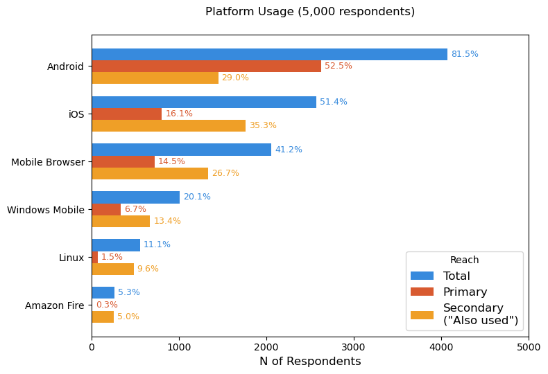

```python
#Define the graph basic parameters

fig, ax = plt.subplots(figsize=(8, 5.5))

n = len(platform_summary)
y      = np.arange(n)
height = 0.25
base   = len(df)

# Create clean y-axis labels
label_map = {
    "android": "Android",
    "ios": "iOS",
    "mobile_browser": "Mobile Browser",
    "windows_mobile": "Windows Mobile",
    "linux": "Linux",
    "amazon_fire": "Amazon Fire"
}

# Use the stats from the previously created df
platforms = platform_summary.index.tolist()
totals    = platform_summary["Total reach"].values
primaries = platform_summary["Primary"].values
alsos     = platform_summary["Also using"].values
platforms_clean = [label_map.get(p, p.replace("_", " ").title()) for p in platforms]

# Three bars per platform: Total (top), Primary (middle), Also using (bottom)
bars_total   = ax.barh(y - height, totals, height, label="Total", color="#378ADD")
bars_primary = ax.barh(y, primaries, height, label="Primary", color="#D85A30")
bars_also    = ax.barh(y + height, alsos, height, label="Secondary\n(\"Also used\")",  color="#EF9F27")

# Create percentage callouts
for bar, val in zip(bars_total,   totals):
    ax.text(bar.get_width() + 40, bar.get_y() + bar.get_height() / 2,
            f"{val / base * 100:.1f}%", va="center", ha="left", fontsize=9, color="#378ADD")

for bar, val in zip(bars_primary, primaries):
    ax.text(bar.get_width() + 40, bar.get_y() + bar.get_height() / 2,
            f"{val / base * 100:.1f}%", va="center", ha="left", fontsize=9, color="#D85A30")

for bar, val in zip(bars_also,    alsos):
    ax.text(bar.get_width() + 40, bar.get_y() + bar.get_height() / 2,
            f"{val / base * 100:.1f}%", va="center", ha="left", fontsize=9, color="#EF9F27")

# Axes and other visuals
ax.set_yticks(y)
ax.set_yticklabels(platforms_clean, fontsize=10)
ax.set_xlim(0, 5000)
ax.set_xlabel("N of Respondents", fontsize=12)
ax.invert_yaxis()  # highest total reach on top

ax.legend(loc="lower right", title = "Reach", fontsize=12)

ax.set_title("Platform Usage (5,000 respondents)", fontsize=12, pad = 20)

# Saving and producing the plot
plt.tight_layout()
plt.savefig("platforms_q10.png", dpi=300, bbox_inches="tight")
plt.show()
```

The chart below focuses on the two platforms that are the subject of this analysis: Android and iOS. For each, it shows what share of that platform's primary developers also target each of the other platforms as secondary - answering the question "if a developer primarily targets Android (or iOS), where else do they build?""

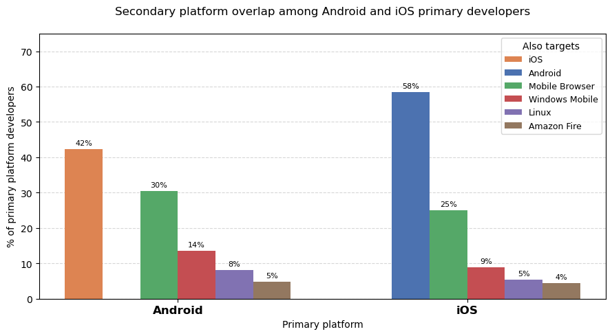

```python
# Secondary platform overlap: Android-primary vs iOS-primary developers
# Calculated as % of each group's primary developers, not % of total sample

focus_platforms = ["Android", "iOS"]
secondary_platforms = ["iOS", "Android", "Mobile Browser", "Windows Mobile", "Linux", "Amazon Fire"]

platform_ids = {
    "Android":        "platform_android",
    "iOS":            "platform_ios",
    "Mobile Browser": "platform_mobile_browser",
    "Windows Mobile": "platform_windows_mobile",
    "Linux":          "platform_linux",
    "Amazon Fire":    "platform_amazon_fire",
}

# Consistent colour per secondary platform
sec_colors = {
    "iOS":            "#DD8452",
    "Android":        "#4C72B0",
    "Mobile Browser": "#55A868",
    "Windows Mobile": "#C44E52",
    "Linux":          "#8172B2",
    "Amazon Fire":    "#937860",
}

x = np.arange(len(focus_platforms))
n_sec = len(secondary_platforms)
bar_width = 0.13
offsets = np.linspace(-(n_sec - 1) / 2, (n_sec - 1) / 2, n_sec) * bar_width

fig, ax = plt.subplots(figsize=(9, 5))

for j, sec_name in enumerate(secondary_platforms):
    pcts = []
    for primary_name in focus_platforms:
        primary_mask = df[platform_ids[primary_name]].eq("Primary")
        # Skip self (Android→Android or iOS→iOS)
        if sec_name == primary_name:
            pcts.append(np.nan)
        else:
            overlap = (primary_mask & df[platform_ids[sec_name]].eq("Also using")).sum()
            pcts.append(overlap / primary_mask.sum() * 100)

    bars = ax.bar(
        x + offsets[j], pcts, bar_width,
        label=sec_name, color=sec_colors[sec_name], zorder=2
    )
    for bar, val in zip(bars, pcts):
        if not np.isnan(val):
            ax.text(
                bar.get_x() + bar.get_width() / 2,
                bar.get_height() + 0.8,
                f"{val:.0f}%",
                ha="center", va="bottom", fontsize=8
            )

ax.set_xticks(x)
ax.set_xticklabels(focus_platforms, fontsize=12, fontweight="bold")
ax.set_ylabel("% of primary platform developers", fontsize=10)
ax.set_xlabel("Primary platform", fontsize=10)
ax.set_title("Secondary platform overlap among Android and iOS primary developers", fontsize=12, pad=20)
ax.set_ylim(0, 75)
ax.yaxis.grid(True, linestyle="--", alpha=0.5, zorder=0)
ax.set_axisbelow(True)

ax.legend(title="Also targets", fontsize=9, loc="upper right")

plt.tight_layout()
plt.savefig("platform_overlap.png", dpi=300, bbox_inches="tight")
plt.show()
```

## Android vs. iOS Developer Profiles

The remainder of the analysis compares developers who list Android as their primary platform against those who list iOS. The focus is on differences that are notable in magnitude and potentially meaningful to a business reader, rather than exhaustively cataloguing all similarities and differences.

Two groups are defined: Android primary developers and iOS primary developers.

```python
android_devs = df[df["platform_android"].eq("Primary")]
ios_devs = df[df["platform_ios"].eq("Primary")]

compare_cols = {
    "Region": "region",
    "Org size": "org_size",
    "Mobile exp": "exp_mobile",
    "Software exp": "exp_software",
    "Target audience": "target_audience",
}

# Loop through single-choice variables, find counts and percentages for Android and iOS devs
for label, col in compare_cols.items():
    android_tot = android_devs[col].value_counts()
    ios_tot = ios_devs[col].value_counts()
    android_pct = android_devs[col].value_counts(normalize=True).mul(100).round(1)
    ios_pct     = ios_devs[col].value_counts(normalize=True).mul(100).round(1)
    difference = android_pct - ios_pct
    summary = pd.DataFrame({"Android n": android_tot, "iOS n":ios_tot, "Android %": android_pct, "iOS %": ios_pct, "difference %":difference}).fillna(0).sort_values("difference %", ascending=False)

    print(f"\n{label}")
    print(summary.to_string())
```

```
Region
                      Android n  iOS n  Android %  iOS %  difference %
region
South Asia                  401     49       15.3    6.1           9.2
Middle East & Africa        485     78       18.5    9.7           8.8
South America               187     28        7.1    3.5           3.6
Eastern Europe              448    132       17.1   16.4           0.7
Oceania                      35     21        1.3    2.6          -1.3
East Asia                   217     78        8.3    9.7          -1.4
Western Europe              526    236       20.0   29.2          -9.2
North America               325    185       12.4   22.9         -10.5

Org size
                            Android n  iOS n  Android %  iOS %  difference %
org_size
Just me                           266     63       14.7    9.2           5.5
2 - 5 employees                   298     99       16.5   14.5           2.0
51 - 500 employees                326    119       18.0   17.4           0.6
501 - 5,000 employees             208     75       11.5   10.9           0.6
6 - 20 employees                  318    127       17.6   18.5          -0.9
5,001 - 10,000 employees           53     28        2.9    4.1          -1.2
21 - 50 employees                 234    109       12.9   15.9          -3.0
More than 10,000 employees        108     65        6.0    9.5          -3.5

Mobile exp
                         Android n  iOS n  Android %  iOS %  difference %
exp_mobile
Mobile apps - < 1 year         843    164       32.1   20.3          11.8
Mobile apps - 1-2 years        900    235       34.3   29.1           5.2
Mobile apps - 3-5 years        592    239       22.6   29.6          -7.0
Mobile apps - 6+ years         289    169       11.0   20.9          -9.9

Software exp
                                 Android n  iOS n  Android %  iOS %  difference %
exp_software
Software in general - 1-2 years        499    100       19.0   12.4           6.6
Software in general - 3-5 years        747    186       28.5   23.0           5.5
Software in general - < 1 year         268     56       10.2    6.9           3.3
Software in general - 6+ years        1110    465       42.3   57.6         -15.3

Target audience
                                  Android n  iOS n  Android %  iOS %  difference %
target_audience
Not sure                                179     36       11.1    7.1           4.0
Developers                               55      7        3.4    1.4           2.0
Small/medium businesses                 237     69       14.7   13.6           1.1
Employees internal to my company         86     31        5.3    6.1          -0.8
Professionals                            91     35        5.6    6.9          -1.3
Consumers                               853    279       52.9   54.9          -2.0
Large enterprises                       112     51        6.9   10.0          -3.1
```

Several meaningful differences emerge from the single-choice comparisons:

**Geography and market economics:** Platform choice is strongly tied to geographic location. Android development is more prevalent in emerging markets (South Asia, Middle East & Africa, South America), while iOS leads in mature, high-income markets (North America, Western Europe).

**Experience and decision-making power:** iOS developers are more experienced professionals, both in mobile development and general software development.

**Organisation size and target audiences:** Android developers are more likely to work alone (14.7% vs 9.2%) and are more commonly uncertain about their target audience (11.1% vs 7.1%). iOS developers are more concentrated in larger enterprises (9.5% vs 6%) and more often target well-defined corporate clients (10% vs 6.9%).

```python
# Multiple-choice variables
multi_compare = {
    "App categories": [c for c in df.columns if c.startswith("cat_")],
    "Roles": [c for c in df.columns if c.startswith("role_")],
    "Languages": [c for c in df.columns if c.startswith("lang_")],
}

for label, cols in multi_compare.items():
    android_tot = android_devs[cols].notna().sum()
    ios_tot = ios_devs[cols].notna().sum()
    android_pct = android_devs[cols].notna().mean().mul(100).round(1)
    ios_pct = ios_devs[cols].notna().mean().mul(100).round(1)
    difference = android_pct - ios_pct
    summary = pd.DataFrame({"Android n": android_tot, "iOS n":ios_tot, "Android %": android_pct, "iOS %": ios_pct, "difference %":difference}).fillna(0).sort_values("difference %", ascending=False)

    summary.index = summary.index.str.replace(r"^(cat|role|lang)_", "", regex=True)
    print(f"\n{label}")
    print(summary.to_string())
```

```
App categories
                Android n  iOS n  Android %  iOS %  difference %
education             302     69       11.5    8.6           2.9
games                 355     88       13.5   10.9           2.6
entertainment         244     58        9.3    7.2           2.1
social                254     62        9.7    7.7           2.0
music_video           159     37        6.1    4.6           1.5
business              394    139       15.0   17.2          -2.2
finance               220     86        8.4   10.7          -2.3
health_fitness        179     78        6.8    9.7          -2.9

Roles
                Android n  iOS n  Android %  iOS %  difference %
data_scientist        181     48        6.9    5.9           1.0
dba                   347    109       13.2   13.5          -0.3
data_analyst          110     40        4.2    5.0          -0.8
sysadmin              288    107       11.0   13.3          -2.3
qa                    227     94        8.7   11.6          -2.9
devops                202     94        7.7   11.6          -3.9
tech_lead             404    187       15.4   23.2          -7.8
architect             552    255       21.0   31.6         -10.6
programmer           1562    574       59.5   71.1         -11.6

Languages
            Android n  iOS n  Android %  iOS %  difference %
java              998    135       38.0   16.7          21.3
kotlin            527     77       20.1    9.5          10.6
csharp            364     74       13.9    9.2           4.7
python            189     36        7.2    4.5           2.7
c_cpp             199     50        7.6    6.2           1.4
visual_dev         86     27        3.3    3.3           0.0
ruby               26      9        1.0    1.1          -0.1
php               136     45        5.2    5.6          -0.4
javascript        589    195       22.4   24.2          -1.8
objc               89    141        3.4   17.5         -14.1
swift             194    288        7.4   35.7         -28.3
```

Differences in app categories are modest overall: Android developers lean slightly more towards Education, Games, Entertainment, Social, and Music/Video, while iOS developers are more represented in Health & Fitness, Finance, and Business - sectors associated with higher willingness-to-pay.

In terms of roles, iOS developers more commonly identify as Programmers, System Architects (31.6% vs 21%), and Tech Leads (23.2% vs 15.4%), consistent with the experience gap noted above. Language usage follows platform conventions: Android developers favour Java and Kotlin, while iOS developers favour Swift and Objective-C.

The two most strategically interesting differences - experience level and geographic distribution - are shown visually below.

### Experience Distribution: Android vs. iOS

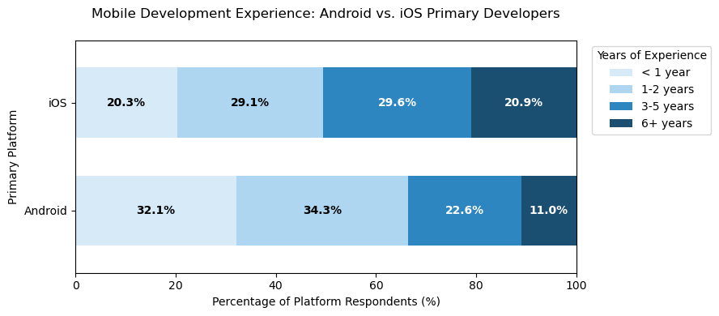

```python
#Categories of experience with mobile
exp_categories = [
    "Mobile apps - < 1 year",
    "Mobile apps - 1-2 years",
    "Mobile apps - 3-5 years",
    "Mobile apps - 6+ years",
]

# Percentages for the two categories
android_counts = (
    android_devs["exp_mobile"]
    .value_counts(normalize=True)
    .reindex(exp_categories)
    .mul(100)
)

ios_counts = (
    ios_devs["exp_mobile"]
    .value_counts(normalize=True)
    .reindex(exp_categories)
    .mul(100)
)

# Create and transpose this percentage data for the graph
df_plot = pd.DataFrame({"Android": android_counts, "iOS": ios_counts}).T
df_plot.columns = df_plot.columns.str.replace("Mobile apps - ", "", regex=False)

# Setup colours (lighter = junior, darker = senior)
colors = ["#D6EAF8", "#AED6F1", "#2E86C1", "#1B4F72"]

# Initiate the graph
fig, ax = plt.subplots(figsize=(9, 4))
df_plot.plot(kind="barh", stacked=True, color=colors, ax=ax, width=0.65)

# Formatting and labels
ax.set_title("Mobile Development Experience: Android vs. iOS Primary Developers", size=12,pad = 20)
ax.set_xlabel("Percentage of Platform Respondents (%)", fontsize=10)
ax.set_ylabel("Primary Platform", fontsize=10)

ax.set_xlim(0, 100)
ax.legend(
    title="Years of Experience",
    bbox_to_anchor=(1.02, 1),
    loc="upper left"
)

# Add centered percentage labels inside each bar segment
for container in ax.containers:
    bar_color = container.patches[0].get_facecolor()
    text_color = "black" if bar_color[0] > 0.5 else "white"

    ax.bar_label(
        container,
        fmt=lambda x: f"{x:.1f}%" if x > 0 else "",
        label_type="center",
        color=text_color,
        fontsize=10,
        fontweight="bold"
    )

plt.tight_layout()
plt.savefig("mobile_exp_comparison.png", dpi=300, bbox_inches="tight")
plt.show()
```

### Regional Distribution: Android vs. iOS

The chart below compares the regional composition of Android and iOS primary developers directly, making it easy to see both the absolute share of each group in a region and the gap between them.

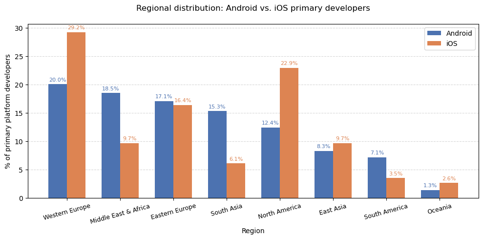

```python
# Regional breakdown: Android vs iOS primary developers
# Shown as % of each group, side by side, for direct comparison

android_pct = android_devs["region"].value_counts(normalize=True).mul(100)
ios_pct     = ios_devs["region"].value_counts(normalize=True).mul(100)

regions = android_pct.index.union(ios_pct.index)
android_vals = [android_pct.get(r, 0) for r in regions]
ios_vals     = [ios_pct.get(r, 0)     for r in regions]

# Sort by Android share descending for a clean reading order
order = sorted(range(len(regions)), key=lambda i: android_vals[i], reverse=True)
regions_sorted      = [regions[i]      for i in order]
android_vals_sorted = [android_vals[i] for i in order]
ios_vals_sorted     = [ios_vals[i]     for i in order]

x = np.arange(len(regions_sorted))
bar_width = 0.35

fig, ax = plt.subplots(figsize=(10, 5))

bars_a = ax.bar(x - bar_width / 2, android_vals_sorted, bar_width,
                label="Android", color="#4C72B0", zorder=2)
bars_i = ax.bar(x + bar_width / 2, ios_vals_sorted,     bar_width,
                label="iOS",     color="#DD8452", zorder=2)

for bar in bars_a:
    ax.text(bar.get_x() + bar.get_width() / 2, bar.get_height() + 0.4,
            f"{bar.get_height():.1f}%", ha="center", va="bottom", fontsize=8, color="#4C72B0")

for bar in bars_i:
    ax.text(bar.get_x() + bar.get_width() / 2, bar.get_height() + 0.4,
            f"{bar.get_height():.1f}%", ha="center", va="bottom", fontsize=8, color="#DD8452")

ax.set_xticks(x)
ax.set_xticklabels(regions_sorted, fontsize=9, rotation=15, ha="center")
ax.set_ylabel("% of primary platform developers", fontsize=10)
ax.set_xlabel("Region", fontsize=10)
ax.set_title("Regional distribution: Android vs. iOS primary developers", fontsize=12, pad=20)
ax.yaxis.grid(True, linestyle="--", alpha=0.5, zorder=0)
ax.set_axisbelow(True)
ax.legend(fontsize=10)

plt.tight_layout()
plt.savefig("region_diverging.png", dpi=300, bbox_inches="tight")
plt.show()
```

## Summary of Key Findings

**Android vs. iOS profiles:**

| Dimension | Android developers | iOS developers |
| --- | --- | --- |
| Geography | Emerging markets (South Asia, MEA, South America) | Mature markets (North America, Western Europe) |
| Experience | Less experienced on average | More experienced; more senior roles |
| Organisation size | More likely to work solo or in small teams | More common in large enterprises |
| Target audience | Consumer apps (Education, Games); often uncertain | Enterprise & premium consumer (Finance, Health, Business) |
| Languages | Java, Kotlin | Swift, Objective-C |

**Strategic implication:**  
Businesses targeting enterprise buyers should prioritise iOS channels. Those targeting emerging markets should prioritise Android. Android developers are better targets for freemium and consultancy-style services; iOS developers are more apt for high-ticket, multi-seat enterprise software licences.